### L1 Introduction to Python Programming for Discovery Skills

# Summative Assignment 4

## Released 14:00 Friday 28th February 2025.

# **Please read the following instructions carefully before beginning the assignment.**

## The questions in this assignment are worth a total of **10 marks**. Each question in this assignment consists of three cells in the notebook, these consist of:

**A Question cell :**

A cell with text describing the question (which you cannot edit).

**An Answer cell:**

Into which you should write your answer to the preceeding question. These cells will contain the comment:

`# YOUR CODE HERE`

To answer each question, you must replace `# YOUR CODE HERE` with your own code, as indicated by the question.

If the questions asks you to define variables or functions with specified names, **you must name them exactly as they are named in the question (including capitalisation), or you will get zero marks for your answer to the corresponding question**

**A Pre-test cell:**

You *may* execute this cell **after** executing the answer cell containing your answer, in order to run a "pre-test" on your answer. Running the pre-test cell executes code that can check, and generate a helpful message, if you have made one of several possible simple mistakes in your code, including creating a function with the wrong name or creating a function that doesn't return anything at all. The pre-test cell will then test your code against one or several simple examples and it will explicitly tell you if your code does **not** give the correct result.

If your answer to a question passes the pre-tests, including giving the correct answer for the test examples, then executing the corresponding pre-test cell will return a message "Your answer to question __ has passed the pre-test".

The pre-test cells contain hidden tests that the auto-grading system will run in order to see if your answer is correct. These tests are different from the visible pre-tests. As a result **if your code passes the pre-test, that does not mean that you have got the correct answer**, it just means that you have not made any obviously silly mistakes (such as naming your function incorrectly) for which I would not want you to lose marks!

To do this assignment, I **strongly recommend that you open another, blank notebook to test your answers to the questions below** . Once you have the code that you think produces the correct answer for a given question, you can then simply copy and paste this into the corresponding answer cell in this assignment. To open a new notebook, go to File >>> New Notebook >>> Python 3 (ipykernel).

# **Check your code for some cases by hand</font>**

This is generally a very good idea; in almost all cases, if there is a minor issue with your code and it doesn't give the correct answer, you will be able to tell this by checking whether your code gives the right answer in a simple case, using a calculator, for example.

# DO NOT write functions that ask for user-input </font>

The autograder, which is used to mark all of the assignments, is not a user. Consequently, when autograding an assignment with functions that ask for user input, the tests will fail and you will not receive any marks for that question, even if the function that you have defined is correct.

## How to Submit Your Assignment:

To submit your assignment, you should go to the Assignments tab *(where you "fetched" this assignment)*. You will see this assignment under "Downloaded Assignments". To the right you will then see a blue "Submit" button which you can click to submit the *latest version of your assignment* .

You may submit this assignment an unlimited number of times, but **only your most recent submission will be marked.**

**Submissions made after the deadline will not be marked.**

# **You MUST submit your assignment manually, as described above. Your assignment will NOT be automatically submitted by saving this notebook.**

## **You can and should check that you have submitted this assignment. To do this, go to your assignment tab and there should be an entry for this assignment under "Submitted Assignments" (below "Released Assignments"), together with a timestamp corresponding to the time that you submitted your assignment. If no such entry appears then you have not yet submitted your assignment**

## You will receive the marks for your latest submission shortly after the deadline, along with a link to see your most recent submission and the solution.

## Note: The "Validate" Button

You may have seen the "Validate" button to the right of this notebook when you loaded it up in the assignments tab. This has the same function as the "Validate" button amongst the other "console buttons" at the top of the screen.

Clicking the validate button runs all of the cells in a notebook and will generate an error if any of the cells in the notebook contained an error. You can use the validate button as a useful way to simultaneously check whether all of your answers pass the pre-tests. If you have already written your answers you should already know whether they pass the pre-tests because you will likely have run the pre-tests individually already, so the validate button will not give you any additional information. However, it may be useful to use it for a final check of your answers before you press "submit" for the last time, for example.

If your notebook passes the validation tests jupyter will bring up a window of Validation Results, including the message "Success! Your notebook passes all the tests."

You don't strictly need to use the validate button in order to do these assignments, but it is useful to know what it does and how it could be useful!

# **You MUST submit your assignment manually. Your assignment will NOT be automatically submitted by saving this notebook.**

# Question 1

Write a function `f1(data, predicted, weights)` (arguments in that order) that calculates the weighted mean squared error, $W$, for a set of data points. Given three **lists**: `data` (the actual values), `predicted` (the predicted values), and `weights` (the weights assigned to each data point), your function should return the weighted mean squared error calculated as follows:

$$W = \frac{\sum_{i=1}^{n} w_i \cdot (y_i - p_i)^2}{\sum_{i=1}^{n} w_i}$$

where $ y_i $ is the measured value, $ p_i $ is the predicted value, $ w_i $ is the weight for the $i$-th data point, and $ n $ is the total number of data points.

### [2 marks]

```python
# YOUR CODE HERE
def f1(data, predicted, weights):
    length = len(data)
    x = 0
    for i in range(0,length):
        x = x + (weights[i] * ((data[i] - predicted[i])**2))
    x1 = x / (sum(weights))
    return x1
print(f1([2.6, 4.2, 4.8, 2.7],[2, 4, 4, 2],[1, 3, 3, 2]))
```

```
0.37555555555555553
```

```python
# PRE-TEST CELL for Q1/
function_name, QN = "f1",1
assert function_name in dir(), "It appears that you may not have defined a function named " + function_name + ", or you may not have executed your answer cell."
function = f1
import numpy as np
test=np.array([1])
assert function([1],[1],[1]) is not None, "It appears that your function " + function_name + " does not return anything"

m = "Your function " + function_name + " does not give the correct answer for at least one of the pre-test examples"
assert function([2.6, 4.2, 4.8, 2.7],[2, 4, 4, 2],[1, 3, 3, 2])==0.37555555555555553
assert function( [4.3, 2.7, 4.3, 4.1], [4, 2, 4, 4], [2, 3, 4, 3]) == 0.17
assert function( [4.0, 1.9, 4.8, 3.2], [3, 1, 4, 3], [3, 2, 1, 1]) == 0.757142857142857
assert function( [3.2, 2.3, 4.7, 2.8], [3, 2, 4, 2], [1, 1, 1, 2]) == 0.3799999999999999
assert function( [3.0, 4.3, 3.7, 2.5], [2, 4, 3, 2], [4, 4, 4, 3]) == 0.4713333333333333
print("Your answer to question",QN,"passed the pre-tests")
```

```
Your answer to question 1 passed the pre-tests
```

# Question 2

Create a function `f2(xdata, ydata)` (arguments in that order) that returns a **numpy array** of the best fit* parameters `[A, B, C, D]` that fit the list `xdata` of $x$ values to the list `ydata` of $y$ values, to an equation of the form $y =$ `A`$x^3$ + `B`$x^2$ `C`$x$ + `D`

*where the fit is determined using a non-linear least-squares regression test (the default fit method of scipy's `curve_fit()` function)

*Emph: It is highly likely that your code may generate a warning including the message "Covariance of the parameters could not be estimated". This is not an error; if your code passes the pre-check it is still very likely that your answer is correct, even if you receive this warning. It could also show this warning when you validate this notebook.*

### [2 marks]

```python
# YOUR CODE HERE
import numpy as np
import scipy.optimize as scpo
def f2(xdata, ydata):
    def func(x,A,B,C,D):
        return (A*(x**3))+(B*(x**2))+(C*x)+D
    actual_fit_parameters, matrix = scpo.curve_fit(func, xdata, ydata)
    array = np.array(actual_fit_parameters)
    return array
f2([0,1,2,3],[0,1,8,27])
```

```
array([ 1.00000000e+00, -2.18225438e-12, -2.17870166e-12,  4.76517425e-24])
```

```python
# PRE-TEST CELL for Q2/
QN = 2
import numpy as np
import warnings
warnings.filterwarnings("ignore", message="Covariance of the parameters could not be estimated")
assert "f2" in dir(), "It appears that you may not have defined a function named `f2`, or you may not have executed your answer cell."
assert type(f2([0,1,2,3],[0,1,8,27])) != None, "It appears that your function `f2` does not return anything"
assert type(f2([0,1,2,3],[0,1,8,27])) != list, "It appears that your function `f2` does not return a list"
assert type(f2([0,1,2,3],[0,1,8,27])) == np.ndarray, "It appears that your function `f2` does not return a numpy array"
m = "Your function `f2` does not give the correct answer for at least one of the pre-test examples"
x = np.linspace(0,10,25)
y1 = [30.390612839315782, 29.228697654997504, 18.568379492151507, 20.166622529721167, 17.188580816887047, 10.712628850689196, 12.529563647043735, 8.467164261318075, -10.99383206870374, -25.214252615514958, -42.511324756333984, -68.94189199528792, -95.33380451524111, -142.30260473504865, -189.02108403024988, -246.26763070120765, -315.36581678039676, -388.7860260409345, -486.52283257766504, -586.0095239982003, -707.2608473684287, -835.8587474323318, -983.4260237484625, -1148.9111947272945, -1329.4564507057503]
A ,B ,C ,D  = -2,8,-16,32
assert np.all(np.isclose(sorted(f2(x,y1)), sorted(np.array([ A,   B, C,  D])), rtol = 0.2)), m
y2 = [17.70423614245058, 17.908686774825142, 13.402854384208128, 27.035760789118587, 31.24906235788994, 54.92796921486448, 88.80158700013378, 140.54130939275126, 196.30410445476264, 280.5118384724175, 387.83792098192976, 507.2072344200353, 653.6019755039587, 834.1689019171508, 1038.8014856145853, 1280.9340448646597, 1543.9345868613354, 1850.812833924454, 2196.7927140692777, 2578.564825864634, 3003.1962563162047, 3478.8299683679265, 3994.2496037745373, 4550.824722287721, 5168.346704234263]
A, B, C, D = 5, 2.5, -10, 21
assert np.all(np.isclose(sorted(f2(x,y2)), sorted(np.array([ A,   B, C,  D])), rtol = 0.2)), m
xnew = np.linspace(-5,5,25)
y3 = [555.5257569948566, 442.0332076835106, 347.5750505678471, 267.38458500459177, 200.09311203559307, 149.1285453781214, 107.36867593145398, 77.45654704230543, 56.13601345215093, 44.779980752250054, 37.652194088059375, 36.616652643512644, 41.626908196840844, 46.71262481247374, 55.60239270860872, 61.841735567651696, 69.98449328144105, 74.57781003797842, 73.45072854799801, 70.22581122307318, 58.30758501363869, 39.894529736019344, 12.819339599546378, -24.92343994182621, -73.27977772724394]
A, B, C, D = -3, 8, 12, 41
assert np.all(np.isclose(sorted(f2(xnew,y3)), sorted(np.array([ A,   B, C,  D])), rtol = 0.2))
print("Your answer to question",QN,"passed all of the pre-tests")
```

```
Your answer to question 2 passed all of the pre-tests
```

# Question 3

Create a function `f3( X, Y, Xerrors, Yerrors, Xlabel, Ylabel)` (arguments in that order) that **returns** a **scatter plot** of the data with $x$ and $y$ values given by the lists `X` and `Y` respectively, $x$ and $y$ error bars given by the lists `Xerrors` and `Yerrors` respectively and that labels the $x$ and $y$ axis, `Xlabel` and `Ylabel` respectively.

*Hint 1: When calling a function to produce a plot, remember that the order of arguments matters!*

*Hint 2: To return a plot you will need to set a plot object to a variable, using `p = plt.errorbar(...)` (for example) and then returning `p`*

### [2 marks]

```
<ErrorbarContainer object of 3 artists>
```

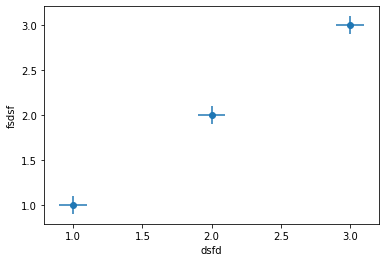

```python
# YOUR CODE HERE
import matplotlib.pyplot as plt
def f3( X, Y, Xerrors, Yerrors, Xlabel, Ylabel):
    p = plt.errorbar(X, Y, xerr = Xerrors , yerr = Yerrors , fmt = 'o')
    plt.xlabel(Xlabel)
    plt.ylabel(Ylabel)
    return p

f3([1,2,3],[1,2,3],[0.1,0.1,0.1],[0.1,0.1,0.1],"dsfd","fsdsf")
```

```python
# PRE-TEST CELL for Q3 - Note: This is much larger than typical pre-test cells!
QN = 3
#check data is plotted correctly
x=[1,3,5,9]
y=[2,4,6,8]
ex=[0.1,12,3.1,9]
ey=[1,7,12,2]
p=f3(x, y, ex, ey, "xlbl", "ylbl")
p=f3(x, y, ex, ey, "xlbl", "ylbl")
xvalues = p[0].get_xdata()
yvalues = p[0].get_ydata()
import numpy as np
assert np.all(xvalues==[1,3,5,9]), "Your function `f3` does not appear to plot the x-axis data correctly."
assert np.all(yvalues==[2,4,6,8]), "Your function `f3` does not appear to plot the y-axis data correctly."
plt.close()
datatest = 1
# check axes are labelled correctly
x=[0,1]
y=[2,4]
ex=[1,1]
ey=[1,1]
f3(x, y, ex, ey, "xlbl", "ylbl")
ax=plt.gca()
xaxislabel=ax.get_xlabel()
yaxislabel=ax.get_ylabel()
assert xaxislabel=="xlbl", "Your function `f3` does not appear to include x labels correctly."
assert yaxislabel=="ylbl", "Your function `f3` does not appear to include y labels correctly."
plt.close()
# check error bars are correctly plotted
x=[4,4,4,4]
y=[4,4,4,4]
ex=[4,3,2,1]
ey=[1,2,3,4]
p=f3(x, y, ex, ey, "f3", "f3")
l1 = p.lines[2][0]
l2 = p.lines[2][1]
xerrpts = l1.get_segments()
yerrpts = l2.get_segments()
xerrors, yerrors=[],[]
max=len(ey)
for i in range (0,max):
    xerrors, yerrors = xerrors + [np.linalg.norm(xerrpts[i][0]-xerrpts[i][1])/2],yerrors + [np.linalg.norm(yerrpts[i][0]-yerrpts[i][1])/2]
import numpy as np
assert np.all(np.isclose(xerrors,ex)), "Your function `f3` does not appear to produce a plot with horizontal error bars as required."
assert np.all(np.isclose(yerrors,ey)), "Your function `f3` does not appear to produce a plot with vertical error bars as required."
plt.close()
print("Your answer to question",QN,"passed all of the pre-tests")
```

```
Your answer to question 3 passed all of the pre-tests
```

# Question 4

The **standard error on the mean** ($\alpha_\mu$) for a sample of size $N$, mean $\mu$ and population standard deviation $\sigma_{N}$, is given by,

$$ \alpha_\mu = \frac{\sigma_{N}}{\sqrt{N-1}} $$

Create a function `f4(data, M)` (arguments in that order) that takes a **list** `data` and returns a **list** of only those entries $x$ of `data` for which $|x - \mu| < M \ \alpha_\mu$ (and that occur in the same order as they occur in the `data`)

### [2 marks]

```python
# YOUR CODE HERE
import numpy as np

def f4(data, M):
    l = len(data)
    mean = sum(data)/l
    z = 0
    for i in range(0,l):
        z = z + ((data[i] - mean)**2)
    std = np.sqrt(z/l)
    stderror = std/(np.sqrt(l-1))
    array = np.array(data)
    list1 = []
    for j in range(0,l):
        if abs(array[j]-mean) < (M*stderror):
            list1.append(data[j])

    return list1
print(f4([4,2,209,198,170,214,210],2))
```

```
[209, 198, 170, 214, 210]
```

```python
# PRE-TEST CELL for Q4/
QN = 4
import numpy as np
assert "f4" in dir(), "It appears that you may not have defined a function named `f4`, or you may not have executed your answer cell."
test = [10,9,1,8,7,25,11,13,-8,8.4]
assert type(f4(test,1)) != None, "It appears that your function 'f4' does not return anything"
assert type(f4(test,1)) != np.ndarray, "It appears that your function 'f4' returns an array, not a list"
assert type(f4(test,1)) == list, "It appears that your function 'f4' does not return a list"
assert len(f4(test,1)) == 6, "It appears that your function 'f4' does not return a list with the correct length"
m = "Your function `f4` does not give the correct answer for at least one of the pre-test examples"
assert np.all(np.isclose(f4(test, 1), [10, 9, 8, 7, 11, 8.4]))
assert np.all(np.isclose(f4([204,207,209,198,170,214,210], 1), [204, 207, 198]))
assert np.all(np.isclose(f4([0.11,0.45,0.23,0.66,0.71,0.33,0.36,0.41], 2), [0.45, 0.33, 0.36, 0.41]))
print("Your answer to question",QN,"passed all of the pre-tests")
```

```
Your answer to question 4 passed all of the pre-tests
```

# Question 5

Create a function named `f5(A, B)` which takes two **lists** `A` and `B` and **returns a list** containing elements, in any order, that are in either `A` or `B` but not in both. The resulting list should not contain any duplicates.

### [2 marks]

```python
# YOUR CODE HERE
def f5(A, B):
    list1 = []
    la = len(A)
    lb = len(B)
    for i in range(0,la):
        if A[i] not in B and A[i] not in list1:
            list1.append(A[i])
    for j in range(0,lb):
        if B[j] not in A and B[j] not in list1:
            list1.append(B[j])
    return list1
print(f5([1,2,3],[1,1,4,4,5,6]))
```

```
[2, 3, 4, 5, 6]
```

```python
# PRE-TEST CELL for Q5/
function_name, QN = "f5",5
assert function_name in dir(), "It appears that you may not have defined a function named " + function_name + ", or you may not have executed your answer cell."
function = f5
assert function([0],[1]) is not None, "It appears that your function " + function_name + " does not return anything"

m = "Your function " + function_name + " does not give the correct answer for at least one of the pre-test examples"
assert function([0],[1])==[0,1]
assert function([0],[0])==[]
assert function([0],[0,1])==[1]
assert function([0,1],[0])==[1]
import numpy as np
import random
for i in range(20):
    a,b,c,d,e,f,g,h = random.sample(range(1, 11), 8)
    assert np.all(np.isclose(sorted(function([a,b,c,d],[a,b,c,d])) , sorted([]))), m
    assert np.all(np.isclose(sorted(function([a,b,c,d],[b,c,d,e])) , sorted([a,e]))), m
    assert np.all(np.isclose(sorted(function([a,b,c,d],[c,d,e,f])) , sorted([a,b,e,f]))), m
    assert np.all(np.isclose(sorted(function([a,b,c,d],[d,e,f,g])) , sorted([a,b,c,e,f,g]))), m
    assert np.all(np.isclose(sorted(function([a,b,c,d],[e,f,g,h])) , sorted([a,b,c,d,e,f,g,h]))), m

print("Your answer to question",QN,"passed the pre-tests")
```

```
Your answer to question 5 passed the pre-tests
```

# **You MUST submit your assignment manually, as described above. Your assignment will NOT be automatically submitted by saving this notebook.**